# My great analysis

Published

September 28, 2026

### Render report

Quarto can render R scripts directly.

This is the code you can use to render this report. This will automatically rename it with today’s date. Note the `eval: false` which makes sure that rendering this report doesn’t run the code to render the report (infinite loop!)

```r
quarto::quarto_render(
  input = "example_spin.R",
  output_file = paste0("example_spin_", Sys.Date(), ".html")
)
```

## Setup

We can use `message: false` to suppress start up package messages (if you like).

```r
library(tidyverse)
```

## Data Exploration

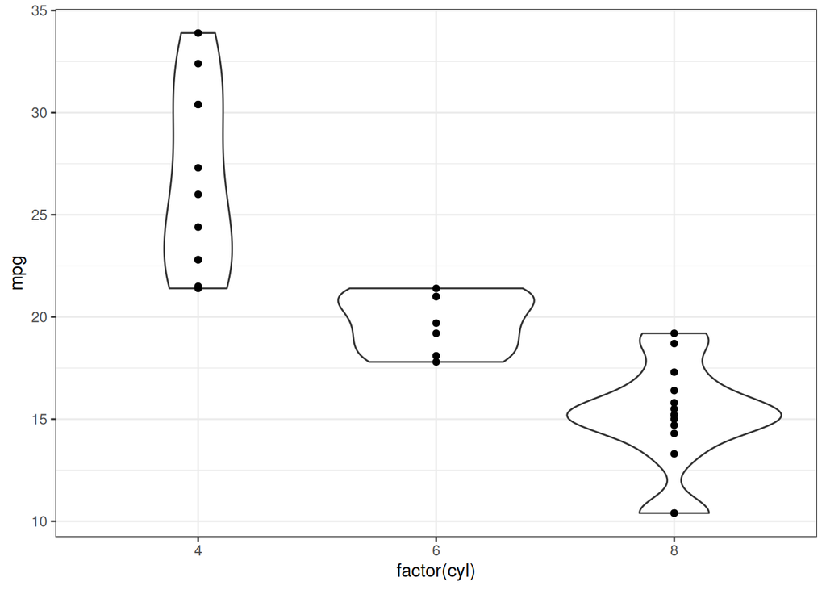

```r
ggplot(data = mtcars, aes(x = factor(cyl), y = mpg)) +
  theme_bw() +
  geom_violin() +
  geom_point()
```

## Analysis

We can use tabs to organize content!

**Main results**

```r
m <- lm(mpg ~ factor(cyl), data = mtcars)
summary(m)
```

```
Call:
lm(formula = mpg ~ factor(cyl), data = mtcars)

Residuals:
    Min      1Q  Median      3Q     Max
-5.2636 -1.8357  0.0286  1.3893  7.2364

Coefficients:
             Estimate Std. Error t value Pr(>|t|)
(Intercept)   26.6636     0.9718  27.437  < 2e-16 ***
factor(cyl)6  -6.9208     1.5583  -4.441 0.000119 ***
factor(cyl)8 -11.5636     1.2986  -8.905 8.57e-10 ***
---
Signif. codes:  0 '***' 0.001 '**' 0.01 '*' 0.05 '.' 0.1 ' ' 1

Residual standard error: 3.223 on 29 degrees of freedom
Multiple R-squared:  0.7325,    Adjusted R-squared:  0.714
F-statistic:  39.7 on 2 and 29 DF,  p-value: 4.979e-09
```

**Model checks**

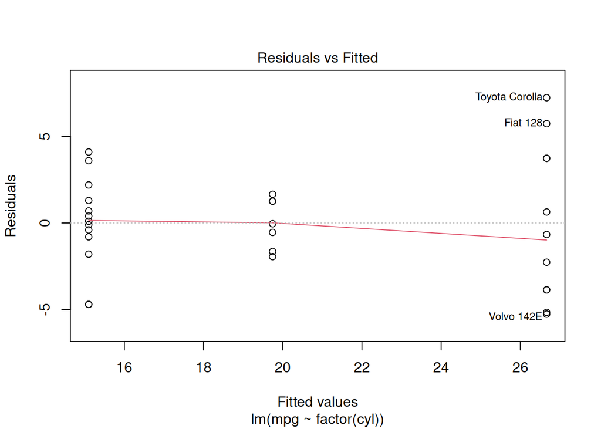

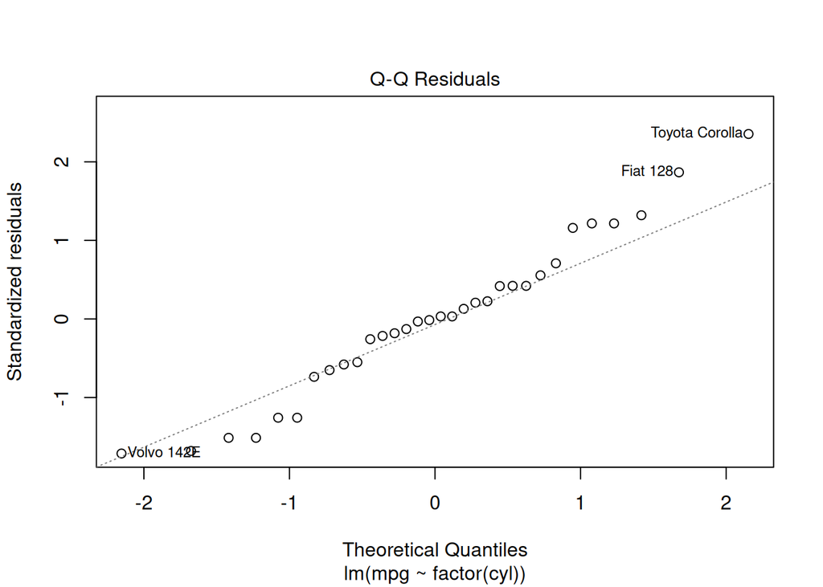

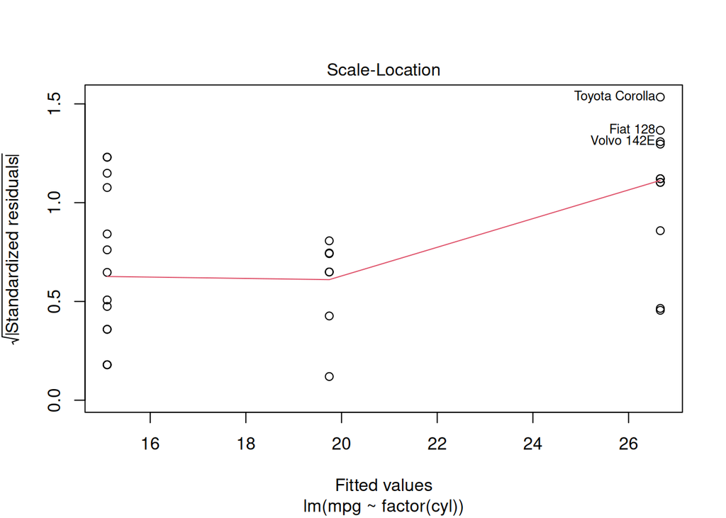

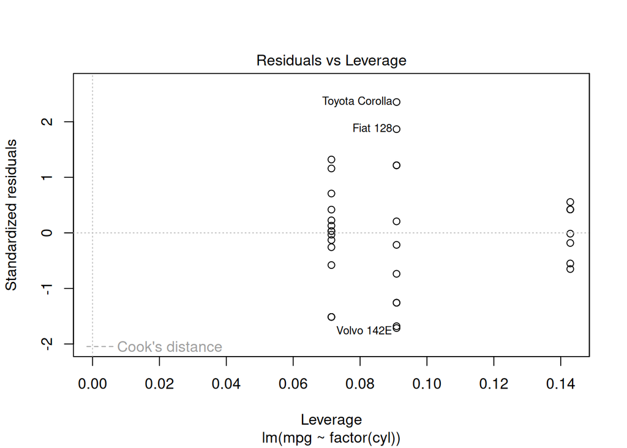

```r
plot(m)
```

## Reproducibility

### Data

Data available for download via CSV/Excel buttons (do not use this as data source, but as confirmation and for posterity)

You can use the HTML `<details><summary></summary></details>` tags to hide content under a button.

**Show data**

```r
DT::datatable(
  mtcars,
  extensions = 'Buttons',
  options = list(dom = 'Bfrtip', buttons = c('csv', 'excel'))
)
```

|  | mpg | cyl | disp | hp | drat | wt | qsec | vs | am | gear | carb |
| --- | --- | --- | --- | --- | --- | --- | --- | --- | --- | --- | --- |
| Mazda RX4 | 21 | 6 | 160 | 110 | 3.9 | 2.62 | 16.46 | 0 | 1 | 4 | 4 |
| Mazda RX4 Wag | 21 | 6 | 160 | 110 | 3.9 | 2.875 | 17.02 | 0 | 1 | 4 | 4 |
| Datsun 710 | 22.8 | 4 | 108 | 93 | 3.85 | 2.32 | 18.61 | 1 | 1 | 4 | 1 |
| Hornet 4 Drive | 21.4 | 6 | 258 | 110 | 3.08 | 3.215 | 19.44 | 1 | 0 | 3 | 1 |
| Hornet Sportabout | 18.7 | 8 | 360 | 175 | 3.15 | 3.44 | 17.02 | 0 | 0 | 3 | 2 |
| Valiant | 18.1 | 6 | 225 | 105 | 2.76 | 3.46 | 20.22 | 1 | 0 | 3 | 1 |
| Duster 360 | 14.3 | 8 | 360 | 245 | 3.21 | 3.57 | 15.84 | 0 | 0 | 3 | 4 |
| Merc 240D | 24.4 | 4 | 146.7 | 62 | 3.69 | 3.19 | 20 | 1 | 0 | 4 | 2 |
| Merc 230 | 22.8 | 4 | 140.8 | 95 | 3.92 | 3.15 | 22.9 | 1 | 0 | 4 | 2 |
| Merc 280 | 19.2 | 6 | 167.6 | 123 | 3.92 | 3.44 | 18.3 | 1 | 0 | 4 | 4 |

[output cut: 22 more lines]

### Packages & Session Info

Make sure you [cite](https://ropensci.org/blog/2021/11/16/how-to-cite-r-and-r-packages/) important packages in your manuscripts.

**Show packages**

```r
report::report_packages(prefix = "- ")
```

- lubridate (version 1.9.5; Grolemund G, Wickham H, 2011)
- tibble (version 3.3.1; Müller K, Wickham H, 2026)
- R (version 4.6.1; R Core Team, 2026)
- ggplot2 (version 4.0.3; Wickham H, 2016)
- forcats (version 1.0.1; Wickham H, 2025)
- stringr (version 1.6.0; Wickham H, 2025)
- tidyverse (version 2.0.0; Wickham H et al., 2019)
- dplyr (version 1.2.1; Wickham H et al., 2026)
- purrr (version 1.2.2; Wickham H, Henry L, 2026)
- readr (version 2.2.0; Wickham H et al., 2026)
- tidyr (version 1.3.2; Wickham H et al., 2025)

```r
report::cite_packages(prefix = "- ")
```

- Grolemund G, Wickham H (2011). “Dates and Times Made Easy with lubridate.” *Journal of Statistical Software*, *40*(3), 1-25. https://www.jstatsoft.org/v40/i03/.
- Müller K, Wickham H (2026). *tibble: Simple Data Frames*. doi:10.32614/CRAN.package.tibble https://doi.org/10.32614/CRAN.package.tibble. R package version 3.3.1, https://CRAN.R-project.org/package=tibble.
- R Core Team (2026). *R: A Language and Environment for Statistical Computing*. R Foundation for Statistical Computing, Vienna, Austria. doi:10.32614/R.manuals https://doi.org/10.32614/R.manuals. https://www.R-project.org/.
- Wickham H (2016). *ggplot2: Elegant Graphics for Data Analysis*. Springer-Verlag New York. ISBN 978-3-319-24277-4. https://ggplot2.tidyverse.org.
- Wickham H (2025). *forcats: Tools for Working with Categorical Variables (Factors)*. doi:10.32614/CRAN.package.forcats https://doi.org/10.32614/CRAN.package.forcats. R package version 1.0.1, https://CRAN.R-project.org/package=forcats.
- Wickham H (2025). *stringr: Simple, Consistent Wrappers for Common String Operations*. doi:10.32614/CRAN.package.stringr https://doi.org/10.32614/CRAN.package.stringr. R package version 1.6.0, https://CRAN.R-project.org/package=stringr.
- Wickham H, Averick M, Bryan J, Chang W, McGowan LD, François R, Grolemund G, Hayes A, Henry L, Hester J, Kuhn M, Pedersen TL, Miller E, Bache SM, Müller K, Ooms J, Robinson D, Seidel DP, Spinu V, Takahashi K, Vaughan D, Wilke C, Woo K, Yutani H (2019). “Welcome to the tidyverse.” *Journal of Open Source Software*, *4*(43), 1686. doi:10.21105/joss.01686 https://doi.org/10.21105/joss.01686.
- Wickham H, François R, Henry L, Müller K, Vaughan D (2026). *dplyr: A Grammar of Data Manipulation*. doi:10.32614/CRAN.package.dplyr https://doi.org/10.32614/CRAN.package.dplyr. R package version 1.2.1, https://CRAN.R-project.org/package=dplyr.
- Wickham H, Henry L (2026). *purrr: Functional Programming Tools*. doi:10.32614/CRAN.package.purrr https://doi.org/10.32614/CRAN.package.purrr. R package version 1.2.2, https://CRAN.R-project.org/package=purrr.
- Wickham H, Hester J, Bryan J (2026). *readr: Read Rectangular Text Data*. doi:10.32614/CRAN.package.readr https://doi.org/10.32614/CRAN.package.readr. R package version 2.2.0, https://CRAN.R-project.org/package=readr.
- Wickham H, Vaughan D, Girlich M (2025). *tidyr: Tidy Messy Data*. doi:10.32614/CRAN.package.tidyr https://doi.org/10.32614/CRAN.package.tidyr. R package version 1.3.2, https://CRAN.R-project.org/package=tidyr.